# Lab 3

Seungah Lee

## Part one: Extracting and loading data

```r
library(readxl)
library(tidyverse)
library(dplyr)

dat <- readxl::read_xls('GSS.xls')
str(dat)
```

```
## tibble [64,816 × 12] (S3: tbl_df/tbl/data.frame)
##  $ Gss year for this respondent       : num [1:64816] 1972 1972 1972 1972 1972 ...
##  $ General happiness                  : chr [1:64816] "Not too happy" "Not too happy" "Pretty happy" "Not too happy" ...
##  $ Religion in which raised           : chr [1:64816] "Not applicable" "Not applicable" "Not applicable" "Not applicable" ...
##  $ Political party affiliation        : chr [1:64816] "Ind,near dem" "Not str democrat" "Independent" "Not str democrat" ...
##  $ Total family income                : chr [1:64816] "Not applicable" "Not applicable" "Not applicable" "Not applicable" ...
##  $ Respondents sex                    : chr [1:64816] "Female" "Male" "Female" "Female" ...
##  $ Highest year of school completed   : chr [1:64816] "16" "10" "12" "17" ...
##  $ Age of respondent                  : chr [1:64816] "23" "70" "48" "27" ...
##  $ Marital status                     : chr [1:64816] "Never married" "Married" "Married" "Married" ...
##  $ Number of hours usually work a week: chr [1:64816] "Not applicable" "Not applicable" "Not applicable" "Not applicable" ...
##  $ Respondent id number               : num [1:64816] 1 2 3 4 5 6 7 8 9 10 ...
##  $ Ballot used for interview          : chr [1:64816] "Not applicable" "Not applicable" "Not applicable" "Not applicable" ...
```

## Part two: Exploration

**0. Use ggplot2 to create the plots, and dplyr to manipulate the data frame as much as possible. You may want to rename the columns of the data frame for your convenience using rename in dplyr.**

```r
dat <- dat %>%
  rename(year = 'Gss year for this respondent',
         happiness = 'General happiness',
         belief = 'Religion in which raised',
         party = 'Political party affiliation',
         income = 'Total family income',
         sex = 'Respondents sex',
         edu = 'Highest year of school completed',
         age = 'Age of respondent',
         marital = 'Marital status',
         work = 'Number of hours usually work a week',
         id = 'Respondent id number',
         ballot = 'Ballot used for interview')

names(dat)
```

```
##  [1] "year"      "happiness" "belief"    "party"     "income"    "sex"
##  [7] "edu"       "age"       "marital"   "work"      "id"        "ballot"
```

**1. Find the average years of education for the respondents with each political party affiliation. Arrange your output in a meaningful order and print. Describe any patterns you find.**

```r
dat$edu <- as.numeric(as.character(dat$edu))
datparty <- dat %>%
  group_by(party) %>%
  summarise(mean = mean(edu, na.rm = TRUE)) %>%
  arrange(mean)
print(datparty)
```

```
## # A tibble: 11 x 2
##    party               mean
##    <chr>              <dbl>
##  1 Don't know          10.9
##  2 No answer           12.3
##  3 Independent         12.3
##  4 Strong democrat     12.5
##  5 Not str democrat    12.6
##  6 Ind,near dem        13.2
##  7 Not str republican  13.3
##  8 Ind,near rep        13.3
##  9 Other party         13.4
## 10 Strong republican   13.4
## 11 <NA>               NaN
```

According to the data, republicans appeared to have the highest average education years. Conversely, those who answered “Don’t know” had the lowest educational training.

**2. Create a single data frame containing records for the better educated respondents in each political party affiliation. A “better educated” respondent is someone who has strictly more years of education than the median in the same party affiliation. Print the structure of the data frame.**

```r
better <- dat %>%
  select(party, edu) %>%
  drop_na %>%
  group_by(party) %>%
  filter(edu > median(edu, na.rm=TRUE))

str(better)
```

```
## tibble [27,840 × 2] (S3: grouped_df/tbl_df/tbl/data.frame)
##  $ party: chr [1:27840] "Ind,near dem" "Not str democrat" "Ind,near dem" "Ind,near dem" ...
##  $ edu  : num [1:27840] 16 17 14 16 13 14 14 17 14 16 ...
##  - attr(*, "groups")= tibble [10 × 2] (S3: tbl_df/tbl/data.frame)
##   ..$ party: chr [1:10] "Don't know" "Ind,near dem" "Ind,near rep" "Independent" ...
##   ..$ .rows: list<int> [1:10]
##   .. ..$ : int [1:5] 837 1083 1137 1262 23661
##   .. ..$ : int [1:3257] 1 3 4 8 16 19 27 35 41 47 ...
##   .. ..$ : int [1:2456] 7 9 11 21 43 53 56 58 59 68 ...
##   .. ..$ : int [1:3852] 23 29 45 48 49 57 62 78 79 102 ...
##   .. ..$ : int [1:148] 299 519 689 897 1007 1102 1191 1482 1513 1648 ...
##   .. ..$ : int [1:5692] 2 13 15 25 28 31 36 38 44 46 ...
##   .. ..$ : int [1:4322] 14 18 20 24 30 33 42 52 65 71 ...
##   .. ..$ : int [1:520] 22 26 61 89 99 111 151 154 192 376 ...
##   .. ..$ : int [1:4537] 5 6 12 17 37 39 40 74 75 76 ...
##   .. ..$ : int [1:3051] 10 32 34 50 51 64 66 88 100 127 ...
##   .. ..@ ptype: int(0)
##   ..- attr(*, ".drop")= logi TRUE
```

**3. How is the happiness of a respondent related to his/her marriage status? Define that a person is happy if the response to question is “Very happy” or “Pretty happy”.**

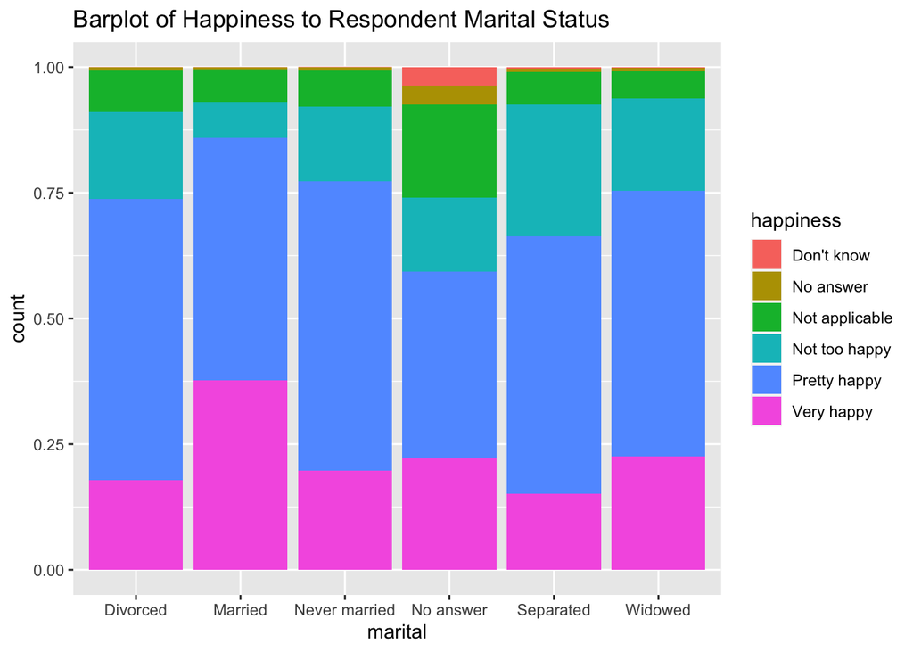

```r
library(ggplot2)

status <- dat %>%
  filter(!is.na(marital)) %>%
  ggplot(aes(x = marital, fill = happiness)) +
  geom_bar(position = 'fill') +
  ggtitle('Barplot of Happiness to Respondent Marital Status')

status
```

```r
very <- dat %>%
  mutate(happy = case_when(
  happiness == "Pretty happy"  ~ "Very Happy"))

very %>%
  group_by(marital, happy) %>%
  drop_na %>%
  summarize(count = n())
```

```
## # A tibble: 6 x 3
## # Groups:   marital [6]
##   marital       happy      count
##   <chr>         <chr>      <int>
## 1 Divorced      Very Happy  4677
## 2 Married       Very Happy 16459
## 3 Never married Very Happy  7940
## 4 No answer     Very Happy     8
## 5 Separated     Very Happy  1144
## 6 Widowed       Very Happy  3255
```

When evaluated based on graphs and numerical, the number and ratio of “Pretty Happy” to “Very Happy” was the highest when the marital status was married. On the contrary, the marital status of separated showed the lowest number of “Pretty Happy” or “Very Happy” when we do not consider the variable no answer.

**4. Does party affiliation affect the relationship you found in the last question?**

```r
partyrelation <- dat %>%
  group_by(marital, happiness, party) %>%
  summarise(count = n()) %>%
  arrange(desc(count))
print(partyrelation)
```

```
## # A tibble: 273 x 4
## # Groups:   marital, happiness [38]
##    marital       happiness    party              count
##    <chr>         <chr>        <chr>              <int>
##  1 Married       Pretty happy Not str democrat    3478
##  2 Married       Pretty happy Not str republican  2865
##  3 Married       Very happy   Not str democrat    2496
##  4 Married       Very happy   Not str republican  2389
##  5 Married       Pretty happy Independent         2323
##  6 Married       Pretty happy Strong democrat     2305
##  7 Married       Pretty happy Ind,near dem        1947
##  8 Married       Very happy   Strong democrat     1841
##  9 Married       Very happy   Strong republican   1778
## 10 Never married Pretty happy Not str democrat    1752
## # … with 263 more rows
```

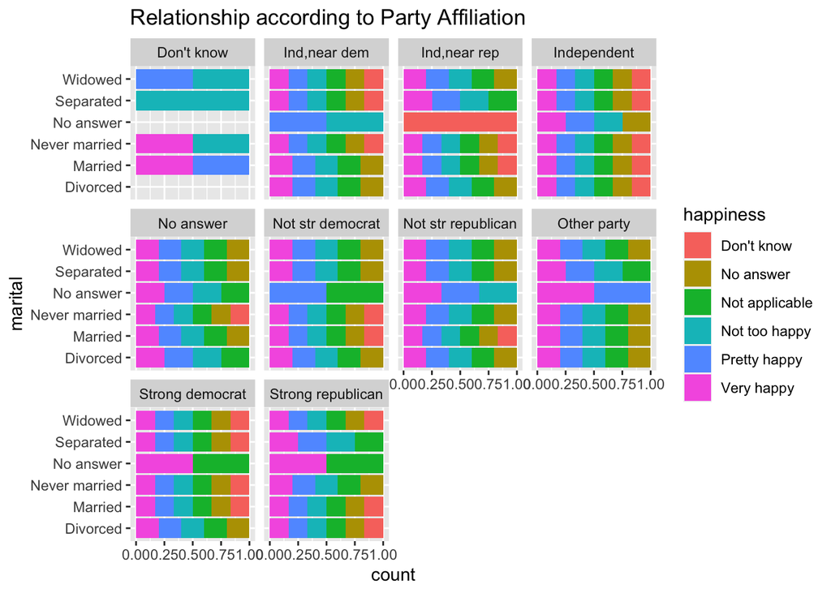

```r
relation <- partyrelation %>%
  select(marital, happiness, party)

relation %>%
  filter(!is.na(happiness)) %>%
  filter(!is.na(marital)) %>%
  ggplot(aes(x = marital, fill = happiness)) +
  geom_bar(position = 'fill') +
  ggtitle('Relationship according to Party Affiliation') +
  facet_wrap(~ party) +
  coord_flip()
```

**5. How is marrital status related to the education of a respondent? What are possible reasons accounting for the patterns you see?**

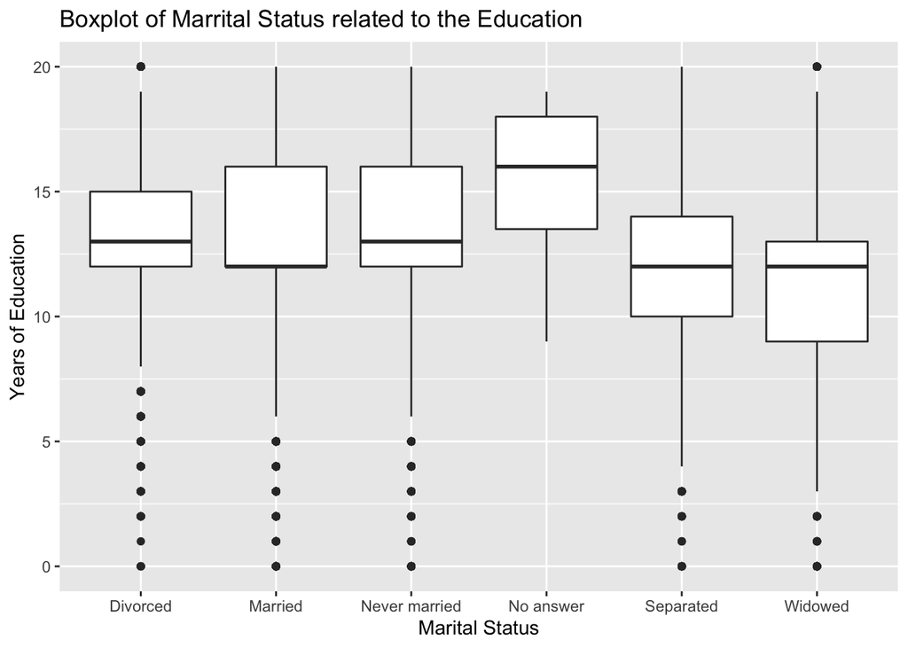

```r
dat %>%
  filter(!is.na(marital)) %>%
  ggplot(aes(x = marital, y = edu)) +
  geom_boxplot() +
  ggtitle('Boxplot of Marrital Status related to the Education') +
  xlab('Marital Status') +
  ylab('Years of Education')
```

```r
dat %>%
  group_by(marital) %>%
  summarise(education = mean(edu, na.rm=TRUE)) %>%
  arrange(desc(education))
```

```
## # A tibble: 7 x 2
##   marital       education
##   <chr>             <dbl>
## 1 No answer          15.5
## 2 Never married      13.4
## 3 Divorced           13.1
## 4 Married            13.0
## 5 Separated          11.9
## 6 Widowed            11.2
## 7 <NA>              NaN
```

When excluding the marital status of ‘No answer’, the average number of years of education was the highest for respondents who were ‘Never married’. This seems to be because unmarried people have more opportunities for education because they have no one to support, such as their spouses or children.

**6. Explore two more interesting questions, and answer those questions using the GSS data.**

##### Q1.How does the marital status affect income?

```r
dat %>%
  group_by(marital, income) %>%
  drop_na %>%
  summarize(count = n()) %>%
  arrange(desc(count))
```

```
## # A tibble: 86 x 3
## # Groups:   marital [6]
##    marital       income         count
##    <chr>         <chr>          <int>
##  1 Married       $25000 or more 18368
##  2 Never married $25000 or more  5376
##  3 Divorced      $25000 or more  3535
##  4 Married       $10000 - 14999  2917
##  5 Married       $20000 - 24999  2689
##  6 Married       $15000 - 19999  2495
##  7 Married       Refused         2206
##  8 Never married $10000 - 14999  1487
##  9 Widowed       $25000 or more  1276
## 10 Never married $15000 - 19999  1183
## # … with 76 more rows
```

[figure not shown]

```r
dat %>%
  filter(!is.na(marital)) %>%
  ggplot(aes(x = marital, fill = income)) +
  geom_bar(position='fill') +
  ggtitle('Boxplot of Marrital Status related to the Education') +
  xlab('Marital Status') +
  ylab('Income index') +
  labs(fill = 'Total Income')
```

Married people overwhelmingly had the highest income. This may be due to the creation of an environment in which two people can earn stable income. The second highest grossing is from unmarried people, who are believed to have made higher income because they have no family to support and can build a stable career.

##### Q2. What is the effect of religion on happiness?

```r
dat %>%
  group_by(belief, happiness) %>%
  summarise(count = n()) %>%
  arrange(desc(count))
```

```
## # A tibble: 80 x 3
## # Groups:   belief [17]
##    belief         happiness      count
##    <chr>          <chr>          <int>
##  1 Protestant     Pretty happy   19592
##  2 Protestant     Very happy     11304
##  3 Catholic       Pretty happy    9640
##  4 Catholic       Very happy      5267
##  5 Protestant     Not too happy   4329
##  6 Catholic       Not too happy   2149
##  7 None           Pretty happy    1867
##  8 Protestant     Not applicable  1611
##  9 Not applicable Not applicable  1518
## 10 None           Very happy       856
## # … with 70 more rows
```

[figure not shown]

```r
dat %>%
  filter(!is.na(belief)) %>%
  ggplot(aes(x = belief, fill = happiness)) +
  geom_bar(position = 'fill') +
  ggtitle('Barplot of Happiness to Respondent Marital Status') +
  theme(axis.text.x = element_text(angle = 90, hjust = 1))
```